# Reciever Reference Game: Yoked Participants

##### Checking for Bad Eggs:

We need to check for folks who may have refreshed the experiment and thus received different amounts of exposure (and likely inconsistent word-object mappings). In this experiment, the people who we have data from who did refresh all did so prior to first exposure, so we don’t need to worry about this. We have already dropped the people who managed to take one of our experiment more than once when reading in our data (our unique turker code was not functioning properly at this time - but this is always a good thing to double check).

### Receiver Data: Basics

Note that in these game data, we have two definitions of ‘exposureRate’. One (‘targetExposure’) refers to how often Ps saw the true target that was originally presented to the sender (this is the target that we used to tell Ps whether they correctly interpreted the messages). The other (‘closestExposure’) refers to how often the object that was communicated about was seen. The two are largely similar, but the distinction is important.

In these data, we have used ‘closestExposure’. Note also that the recognition data coming from games is, of course, filtered only to game trials where labels were used.

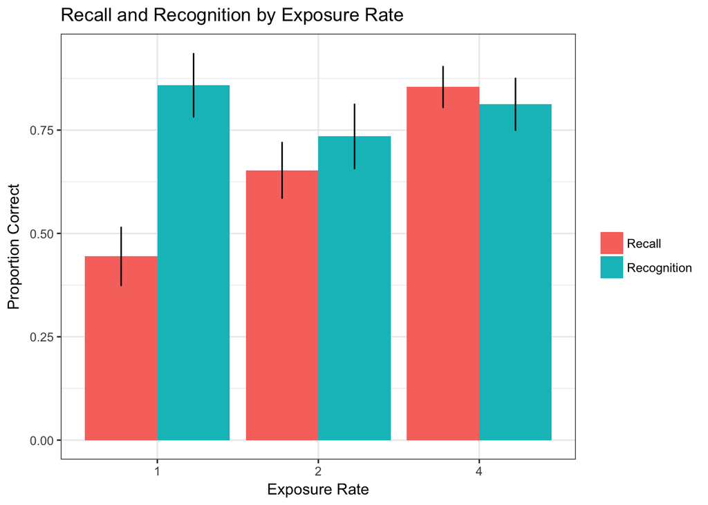

As you can see in the plot above, the red bars show performance at initial test (a simple recall task). Here, performance scales well with exposure as we expected.

Unexpectedly, participants are doing remarkably well at recognizing low frequency words during the game. We expect that this is likely a fluke in this sample as there knowledge of those words at test was also higher than we have seen in the other experiments using this paradigm. There are also fewer trials that involve these labels, so more possibility for a noisy estimate. A cleaner estimate would likely come from un-yoked, label-only input where all words in the lexicon were covered (a follow-up we have done [see reciever_clean]).  
Let’s see how performance in the game scales with performance at test.

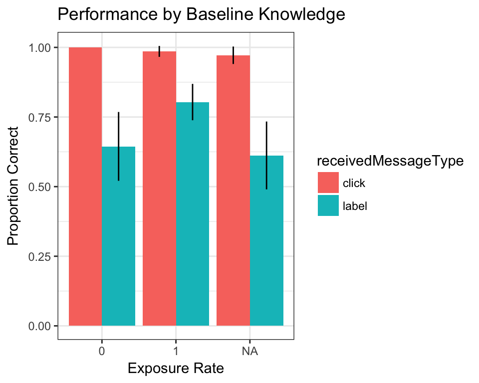

The above plot shows that recognition performance does seem to map onto knowledge at test, a nice check considering the earlier concern that it is less preditcable by exposure rate.

#### Plotting receiver version data

If we look at receiver perfomance as a function of both exposure rates and knowledge at test, these data continue to show bizarrely strong performance with the low frequency words (left most bars in the plot below), but more concerningly, the pattern based on knowledge at test seems broken for the low frequency words…

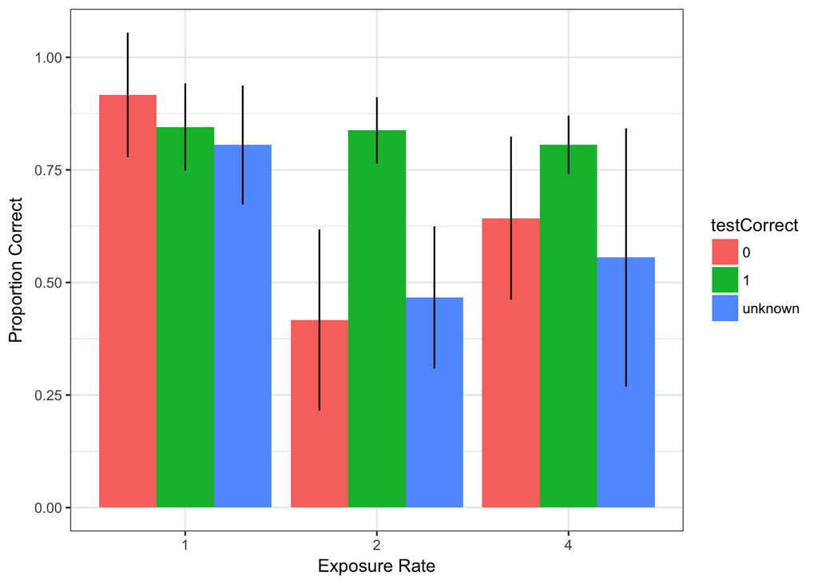

### Adapting Behavior On-Line

How do participants respond to feedback that they selected the wrong object based on the message they received?  
Across all the frequencies, articpants seem to be much more likely to switch the object they selected following the feedback that they were wrong when they last saw that object, compared with when they selected the correct object the previous time.  
Again, there is not a clear pattern with exposure rate, but this should be taken with a grain of salt given the pecularities of this sample.

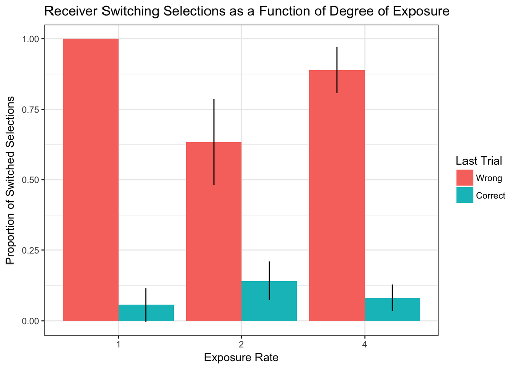

We are also interested in how likely people are to be correct in these situations where they have switched their selections following an incorrect response (blue bars).

It is very difficult to establish an appropriate baseline by which to judge how notable these values are. We have given performance in general on first appearances as a frame of reference (red bars). If participants were to guess truly randomly, they would have a 12.5% (1 in 8) chance of selecting the true referent. While participants are likely guessing more inteligently, we have also plotted this baseline as a floor estimate of where performance should be (dashed line).

Participants are clearly performing better than would be expected by truly random chance (dashed line). Exposure rate is, again, not obviously related in this sample.

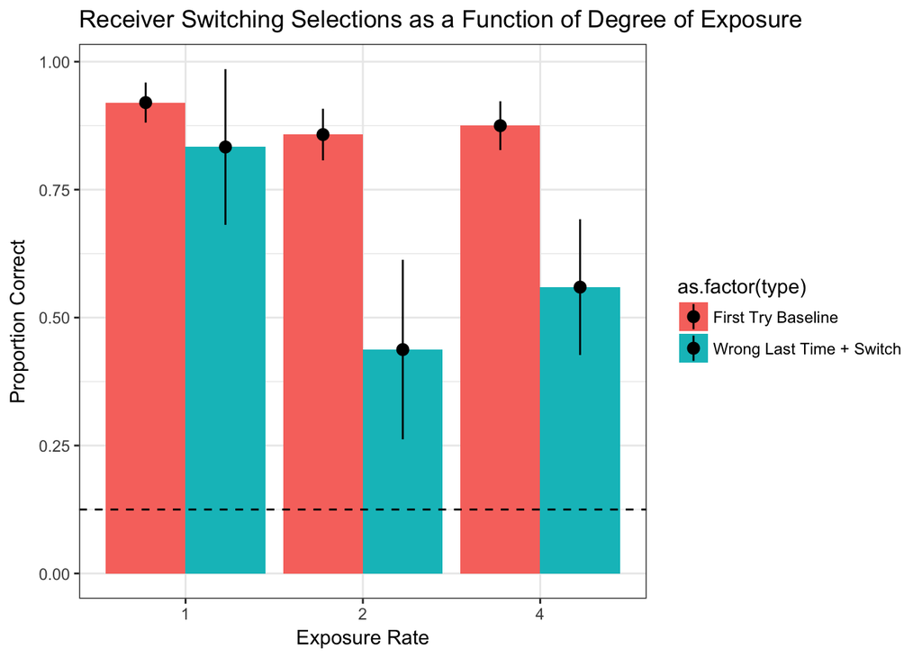

# —————————————————————————

# ————————–other stuff——————————–

# —————————————————————————

## Lev Distance

The code here may not be functioning properly with regard to the predictions. But what we can see that at a lev distance of 2 seems to be a good benchmark to use when coding receiver behavior in this game.

```
## # A tibble: 5 × 4
##    dist receiverCorrect     n          prob
##   <dbl>           <dbl> <int>         <dbl>
## 1     0             224   243 1.605185e-187
## 2     1              36    45  1.362733e-26
## 3     2              10    21  2.768996e-05
## 4     3               2     6  1.156102e-01
## 5     4               1     2  1.975309e-01
```

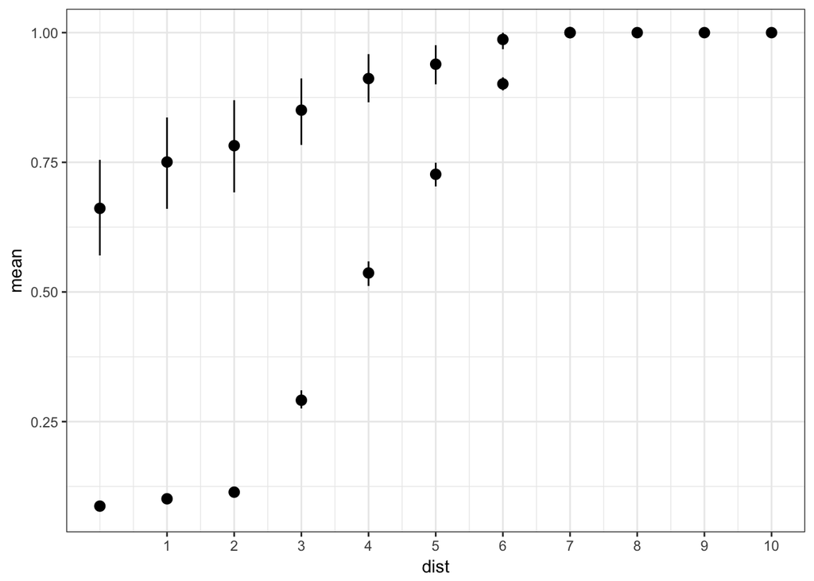

```
## # A tibble: 2 × 4
##   receiverCorrect  avgDist avgNeighbors     n
##             <dbl>    <dbl>        <dbl> <int>
## 1               0 1.593750     2.062500    32
## 2               1 1.283333     2.016667    60
```

```
## Source: local data frame [92 x 9]
## Groups: subID, condition, closestExposure, gameClosest [48]
##
##    condition closestExposure subID targetLabel typedLabel gameClosest
##        <chr>           <int> <chr>       <chr>      <chr>       <chr>
## 1     100_30               4     2       kreeb      kreeg       kreeb
## 2     100_30               2     2         kiv        vic         kiv
## 3     100_30               2     2        manu      mannu        manu
## 4     100_30               4     2       kreeb      kreeg       kreeb
## 5     100_30               2     2        manu      mannu        manu
## 6     100_30               2     2         kiv        vic         kiv
## 7     100_30               1    12     blicket     bicket     blicket
## 8     100_30               1    12     blicket     bicket     blicket
## 9      80_50               4    55         kiv        kiz         kiv
## 10     80_50               4    55         kiv        kiz         kiv
## # ... with 82 more rows, and 3 more variables: minDist <dbl>,
## #   n_Close <int>, clickedLabel <chr>
```

### Duration based exposure measure? hmmm

##### A note about lev distances….

##### timing data X phase

how much will it add to add more game trials?

##### looking for bad eggs in receiver data